# Use case 3: Xhosa data

In all the preceding tutorials we covered languages that do have pre-trained models and dictionaries in the MFA repository. In this notebook we will work on Xhosa data, a language that has neither a MFA dictionary nor an acoustic model. Fortunately, it is sometimes possible to use resources from other projects. An example is the LWAZI project that aimed to develop speech technology resources for several South African languages. We can use the dictionary that was created in this project for our needs (for the original files, see [here](https://repo.sadilar.org/handle/20.500.12185/461).

Download the Xhosa_dataset.zip and the Xhosa.txt and Xhosa_wordlist.txt files, that can be found in the Google Drive. The Xhosa dataset contains audio recordings and transcriptions, the Xhosa.txt is a dictionary and Xhosa_wordlist.txt is a list of all words in the transcription.

Unzip the dataset first. We will run at first the validate command of the MFA:

```python
! mfa validate ~/Workspace/corpora/Xhosa_dataset/ ~/Workspace/corpora/Xhosa.txt
```

```
WARNING - The previous run had a different configuration than the current, which
                   may cause issues. Please see the log for details or use
                   --clean flag if issues are encountered.
INFO - Setting up corpus information...
INFO - Loading corpus from source files...
2420it [00:01, 1520.57it/s]
INFO - Found 12 speakers across 2420 files, average number of utterances per
                speaker: 201.66666666666666
INFO - Initializing multiprocessing jobs...
INFO - Normalizing text...
INFO - Creating corpus split for feature generation...
INFO - Generating MFCCs...
2439it [00:18, 130.99it/s]
INFO - Calculating CMVN...
INFO - Generating final features...
INFO - Creating corpus split with features...

INFO - ******
INFO - Corpus
INFO - ******

INFO -   2420 sound files
INFO -   2420 text files
INFO -   12 speakers
INFO -   2420 utterances
INFO -   11179.284 seconds total duration

INFO -   Sound file read errors
INFO -   ======================

INFO -     There were no issues reading sound files.

INFO -   Feature generation
INFO -   ==================

INFO -     There were no utterances missing features.

INFO -   Files without transcriptions
INFO -   ============================

```

[output cut: 133 more lines]

```
INFO - Accumulating statistics...
INFO - monophone - Iteration 39 of 40
INFO - Accumulating statistics...
INFO - monophone - Iteration 40 of 40
INFO - Accumulating statistics...
INFO - Training complete!
INFO - Compiling training graphs...
INFO - Generating alignments...
INFO - Accumulating transition stats...
INFO - Finished accumulating transition stats!
INFO - Beginning phone LM training...
INFO - Collecting training data...
INFO - Training model...
INFO - Completed training in 294.91183066368103 seconds!
INFO - Done! Everything took 324.102 seconds
```

As we can see under "Dictionary", we have a lot of OOV words, so the dictionary covers not the entire corpus. Therefore we have to add all the entries manually, which will be a lot of work, or we create a new dictionary using a g2p model. A g2p model is also missing, so we have to train one on the Xhosa.txt dictionary.

The training of the g2p model is achieved by the following command (adapt paths):

```python
! mfa train_g2p ~/Workspace/corpora/Xhosa.txt ~/Workspace/corpora/Xhosa_g2p.zip
```

[output not shown]

Since we have now our g2p model, we can create the new dictionary based on the wordlist that contains all the words in our transcriptions. We use the following command:

```python
! mfa g2p ~/Workspace/corpora/Xhosa_wordlist.txt ~/Workspace/corpora/Xhosa_g2p.zip ~/Workspace/corpora/Xhosa_dict.txt
```

```
INFO - Generating pronunciations...
INFO - Done! Everything took 2.519 seconds
```

When we look at the dictionary, we will see that this is not perfect. There are a lot of pronunciation alternations generated by the g2p model and most of them may not be accurate. However, we do this whole procedure to illustrate the workflow. Normally, at this point we would correct the dictionary and remove all unnecessary entries.

But for now we will train now our acoustic model on the corpus data and the dictionary by the following command:

```python
! mfa train ~/Workspace/corpora/Xhosa_dataset/ ~/Workspace/corpora/Xhosa_dict.txt ~/Workspace/corpora/Xhosa_am.zip
```

```
INFO - Setting up corpus information...
INFO - Loading corpus from source files...
2420it [00:01, 1538.83it/s]
INFO - Found 12 speakers across 2420 files, average number of utterances per
                speaker: 201.66666666666666
INFO - Initializing multiprocessing jobs...
INFO - Normalizing text...
INFO - Creating corpus split for feature generation...
INFO - Generating MFCCs...
2435it [00:18, 133.23it/s]
INFO - Calculating CMVN...
INFO - Generating final features...
INFO - Creating corpus split with features...
INFO - Initializing training for monophone...
INFO - Compiling training graphs...
INFO - Generating initial alignments...
INFO - Initialization complete!
INFO - monophone - Iteration 1 of 40
INFO - Generating alignments...
INFO - Accumulating statistics...
INFO - monophone - Iteration 2 of 40
INFO - Generating alignments...
INFO - Accumulating statistics...
INFO - monophone - Iteration 3 of 40
INFO - Generating alignments...
INFO - Accumulating statistics...
INFO - monophone - Iteration 4 of 40
INFO - Generating alignments...
INFO - Accumulating statistics...
INFO - monophone - Iteration 5 of 40
INFO - Generating alignments...
INFO - Accumulating statistics...
INFO - monophone - Iteration 6 of 40
INFO - Generating alignments...
INFO - Accumulating statistics...
INFO - monophone - Iteration 7 of 40
INFO - Generating alignments...
INFO - Accumulating statistics...
INFO - monophone - Iteration 8 of 40
INFO - Generating alignments...
```

[output cut: 560 more lines]

[output not shown]

We can now align our files using the dataset, our generated dictionary and the Xhosa acoustic model. The alignments will be saved into a folder called "Xhosa_alignments".

```python
! mfa align ~/Workspace/corpora/Xhosa_dataset/ ~/Workspace/corpora/Xhosa_dict.txt ~/Workspace/corpora/Xhosa_am.zip ~/Workspace/corpora/Xhosa_alignments/
```

```
INFO - Setting up corpus information...
INFO - Loading corpus from source files...
INFO - Found 12 speakers across 2420 files, average number of utterances per
                speaker: 201.66666666666666
INFO - Initializing multiprocessing jobs...
INFO - Normalizing text...
INFO - Creating corpus split for feature generation...
INFO - Generating MFCCs...
2433it [00:19, 127.67it/s]
INFO - Calculating CMVN...
INFO - Generating final features...
INFO - Creating corpus split with features...
INFO - Compiling training graphs...
INFO - Performing first-pass alignment...
INFO - Generating alignments...
INFO - Calculating fMLLR for speaker adaptation...
INFO - Performing second-pass alignment...
INFO - Generating alignments...
INFO - Exporting alignment TextGrids to
                /home/philipp/Workspace/corpora/Xhosa_alignments...
INFO - Finished exporting TextGrids to
                /home/philipp/Workspace/corpora/Xhosa_alignments!
INFO - Done! Everything took 127.359 seconds
```

We can now look at our TextGrids. Words are well-aligned in general and phone alignments are usable. Recall again that we had a lot of variation in our dictionary and that we not corrected it, so the resulting phone alignments may not be accurate. It is thus important to check the pronunciations listed in the dictionary and to correct the dictionary if necessary.

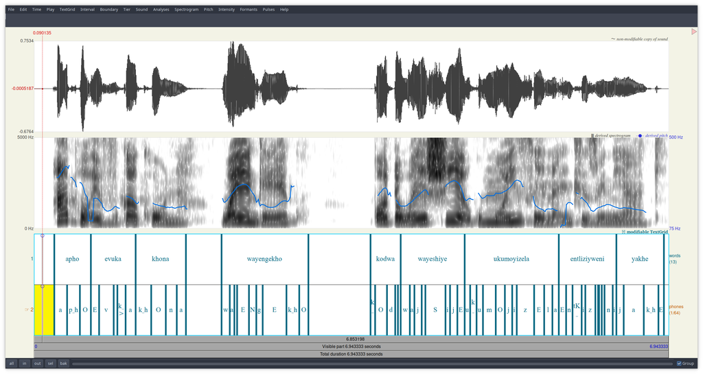